# ETC5523 Assignment 3

Ibrahim Al-Hindi

2021-11-03

# 1 Exercise 1

```r
library(tidyverse)
library(janitor)
library(kableExtra)
library(tidytext)
```

```r
# load data and create "role" column to identify roles when the data is combined
da <- read_csv("data/DataAnalyst.csv") %>% mutate(role = "Data Analyst")
ba <- read_csv("data/BusinessAnalyst.csv") %>% mutate(role = "Business Analyst")
ds <- read_csv("data/DataScientist.csv") %>% mutate(role = "Data Scientist")

# combine into one dataframe and change "role" to factor
combined <- rbind(da, ba, ds) %>%
  mutate(role = factor(role))
```

## 1.1 Question a

The names of the columns will be adjusted to a correct format

```r
combined <- clean_names(combined)
```

The following variables will be examined and edited if necessary

### 1.1.1 `salary_estimate`

The information contained in `salary_estimate` will be used to create four new columns:

- `min_salary`: the minimum salary in the salary range. Missing will be set to “-1”. Numeric
- `max_salary`: the maximum salary in the salary range. Missing will be set to “-1”. Numeric
- `basis`: per annum or per hour. Missing will be set to “-1”. Factor
- `source`: provided by Glassdoor or Employer. Missing will be set to “-1”. Factor

```r
combined <- combined %>%
  mutate(min_salary = as.numeric(ifelse(salary_estimate == -1, -1, str_extract(salary_estimate, "(?<=^\\$)\\d{1,3}"))),
         max_salary = as.numeric(ifelse(salary_estimate == -1, -1, str_extract(salary_estimate, "(?<=-\\$)\\d{1,3}"))),
         salary_basis = as.factor(case_when
                                  (str_detect(salary_estimate, "Hour") ~ "hourly",
                                    salary_estimate == -1 ~ "-1",
                                    TRUE ~ "annual")),
         salary_source = as.factor(case_when
                                   (str_detect(salary_estimate, "Employer") ~ "Employer",
                                     salary_estimate == -1 ~ "-1",
                                     TRUE ~ "Glassdoor")),
         .after = salary_estimate) %>%

  # multiply the min_salary and max_salary by 1,000 if the salary_basis is annual
  mutate(min_salary = ifelse(salary_basis == "annual", min_salary * 1000, min_salary),
         max_salary = ifelse(salary_basis == "annual", max_salary * 1000, max_salary))
```

Check the salary ranges are valid and reasonable for each of annually and hourly

```r
combined %>% filter(salary_estimate != "-1") %>%
  group_by(salary_basis) %>%
  summarise(min_salary_minimum = min(min_salary),
            min_salary_maximum = max(min_salary),
            max_salary_minimum = min(max_salary),
            max_salary_maximum = max(max_salary)) %>%
  kable(col.names = c("basis", "minimum min_salary", "maximum min_salary", "minimum max_salary", "maximum max_salary"),
        format.args = list(big.mark = ',')) %>%
  kable_styling(bootstrap_options = c("striped", "hover"))
```

| basis | minimum min_salary | maximum min_salary | minimum max_salary | maximum max_salary |
| --- | --- | --- | --- | --- |
| annual | 12,000 | 200,000 | 38,000 | 254,000 |
| hourly | 10 | 34 | 26 | 53 |

The salary ranges for both on a per annum and per hour basis are valid and reasonable

### 1.1.2 `rating`

The range of `rating` will be checked to be between 1 and 5 after removing observations with a missing rating

```r
combined %>% filter(rating != -1) %>%
  summarise(minimum = min(rating),
            maximum = max(rating)) %>%
  kable() %>%
  kable_styling(bootstrap_options = c("striped", "hover"))
```

| minimum | maximum |
| --- | --- |
| 1 | 5 |

The ratings are in the valid range. No edits are necessary

### 1.1.3 `company_name`

If the rating for a row is provided, the company name under `company_name` includes the rating for that company at the end of the name. This rating will be removed from the name. The name and the rating are separated by a new line character

```r
combined <- combined %>%
  mutate(company_name = str_remove(company_name, "\\n.*"))
```

### 1.1.4 `location`

`location` will be split to create a column that contains the city and initials of the state separately

```r
combined <- combined %>%
  separate(location, c("city", "state"), sep = ", ")
```

The unique values of `state` will be examined

```r
unique(combined$state)
```

```
##  [1] "NY"             "NJ"             "UT"             "CA"
##  [5] "VA"             "FL"             "IL"             "TX"
##  [9] "AZ"             "PA"             "DE"             "OH"
## [13] "NC"             "SC"             "IN"             "WA"
## [17] "GA"             "KS"             "CO"             "Arapahoe"
## [21] "Los Angeles"    "United Kingdom"
```

The following adjustments will be made:

1. **Arapahoe** will be switched to “CO” since it is part of Colorado
2. **Los Angeles** will be switched to “CA” since it is part of California
3. Jobs in the **United Kingdom** will be removed

```r
combined <- combined %>%
  filter(state != "United Kingdom") %>%
  mutate(state = case_when(
    state == "Arapahoe" ~ "CO",
    state == "Los Angeles" ~ "CA",
    TRUE ~ state))
```

### 1.1.5 `size`

`size` will be converted to an ordinal factor

```r
unique(combined$size)
```

```
## [1] "201 to 500 employees"    "10000+ employees"
## [3] "1001 to 5000 employees"  "501 to 1000 employees"
## [5] "5001 to 10000 employees" "1 to 50 employees"
## [7] "51 to 200 employees"     "Unknown"
## [9] "-1"
```

```r
combined <- combined %>%
  mutate(size = factor(size, levels = c( "Unknown", "1 to 50 employees", "51 to 200 employees", "201 to 500 employees", "501 to 1000 employees", "1001 to 5000 employees", "5001 to 10000 employees", "10000+ employees", "-1")))
```

### 1.1.6 `founded`

`founded` will be checked to be in a reasonable range after filtering out observations with missing values

```r
combined %>% filter(founded != -1) %>%
  summarise(minimum = min(founded),
            maximum = max(founded))
```

```
## # A tibble: 1 x 2
##   minimum maximum
##     <dbl>   <dbl>
## 1    1625    2020
```

The oldest company in the data is quite old. Let us examine this company

```r
combined %>% filter(founded == 1625) %>%
  pull(company_name) %>%
  unique()
```

```
## [1] "City of New York"
```

It is reasonable that the City of New York is that old. Therefore, no changes will be made to `founded`.

### 1.1.7 `revenue`

`revenue` will be converted to an ordinal factor

```r
unique(combined$revenue)
```

```
##  [1] "$100 to $500 million (USD)"       "$2 to $5 billion (USD)"
##  [3] "Unknown / Non-Applicable"         "$50 to $100 million (USD)"
##  [5] "$1 to $2 billion (USD)"           "$5 to $10 billion (USD)"
##  [7] "$1 to $5 million (USD)"           "$25 to $50 million (USD)"
##  [9] "$10+ billion (USD)"               "Less than $1 million (USD)"
## [11] "$10 to $25 million (USD)"         "-1"
## [13] "$500 million to $1 billion (USD)" "$5 to $10 million (USD)"
```

```r
combined <- combined %>%
  mutate(revenue = factor(revenue, levels = c("Less than $1 million (USD)", "$1 to $5 million (USD)", "$5 to $10 million (USD)", "$10 to $25 million (USD)", "$25 to $50 million (USD)", "$50 to $100 million (USD)", "$100 to $500 million (USD)", "$500 million to $1 billion (USD)", "$1 to $2 billion (USD)", "$2 to $5 billion (USD)", "$5 to $10 billion (USD)", "$10+ billion (USD)", "Unknown / Non-Applicable", "-1")))
```

### 1.1.8 `easy_apply`

`easy_apply` that are easy will be changed from “TRUE” to “yes” to avoid possible impacts to future codes, it will also be changed to a factor

```r
combined <- combined %>%
  mutate(easy_apply = factor(ifelse(easy_apply == "TRUE", "yes", easy_apply)))
```

## 1.2 Question b

There are 21 job listings that provide salary intervals on a per hour basis

## 1.3 question c

### 1.3.1 i. Salary Intervals

The salary intervals between the different roles will now be compared. For the purposes of our analysis, only annual figures will be considered.

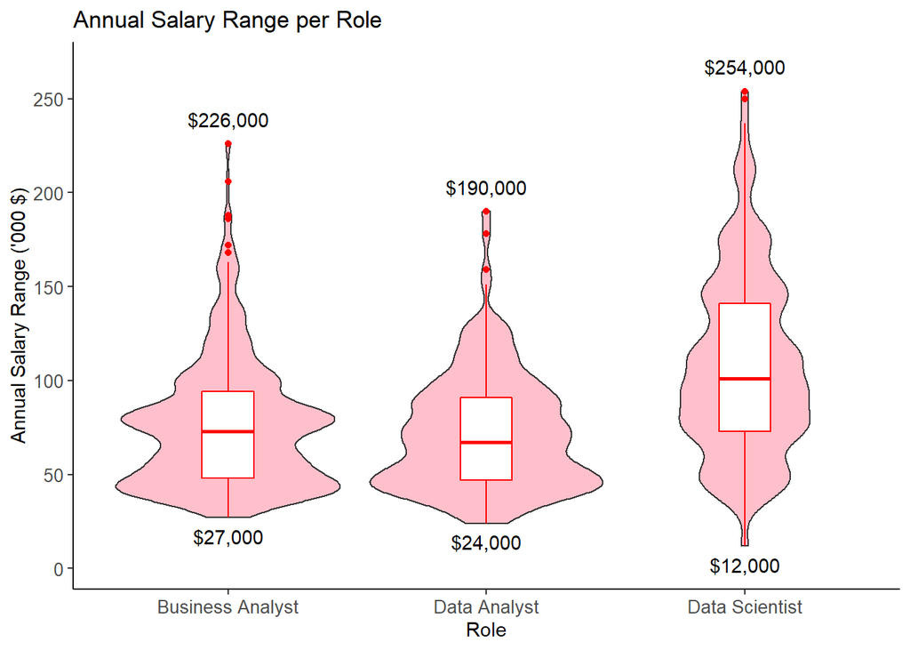

Figure 1.1: Annual salary range per role. Data Scientists have the largest range

```r
combined_sal <- combined %>%
  filter(salary_estimate != "-1",
         salary_basis == "annual") %>%
  group_by(role) %>%
  summarise(range = c(min_salary,max_salary),
            minimum = min(min_salary),
            maximum = max(max_salary)) %>%
  ungroup()

combined_sal_lab <- combined_sal %>%
  group_by(role) %>%
  summarise(minimum = min(minimum),
            maximum = max(maximum))

ggplot(combined_sal, aes(role)) +
geom_violin(aes(y = range/1000), fill = "pink") +
geom_boxplot(aes(y = range/1000), color = "red", width = .2) +
geom_text(data = combined_sal_lab, aes(y = minimum/1000, label = scales::dollar(minimum)), nudge_y = -10) +
geom_text(data = combined_sal_lab, aes(y = maximum/1000, label = scales::dollar(maximum)), nudge_y = 13) +
scale_y_continuous(breaks = seq(0, 250, 50)) +
theme_classic() +
labs(x = "Role",
     y = "Annual Salary Range ('000 $)",
     title = "Annual Salary Range per Role") +
theme(axis.text = element_text(size = 10))
```

1.1 shows that Data Scientists have the largest range and furthest extremes regarding the annual salary by possessing the lowest possible salary at $12,000 and the highest possible salary at $254,000. While business and data analysts possess a similar lowest salary at $27,000 and $24,000, respectively, business analysts have a higher possible salary at $226,000 compared to $190,000 that can be earned by data analysts. In addition, data scientists have a higher median salary at $101,000 versus $73,000 and $67,000 earned by business and data analysts, respectively. Furthermore, while the salaries for business and data analysts are concentrated towards the lower part of the range, the salary range for data scientists is more evenly distributed

The salary intervals minimums and maximums will now be analysed. We will start with the minimum salary range

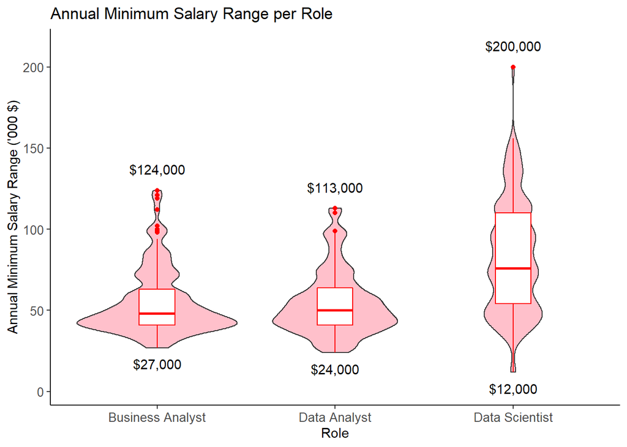

Figure 1.2: Annual minimum salary range per role. Data Scientists have the largest range

```r
combined_sal_min <- combined %>%
  filter(salary_estimate != "-1",
         salary_basis == "annual") %>%
  group_by(role) %>%
  summarise(minimum = min(min_salary),
            maximum = max(min_salary))


combined %>%
  filter(salary_estimate != "-1",
         salary_basis == "annual") %>%
  ggplot(aes(role)) +
  geom_violin(aes(y = min_salary/1000), fill = "pink") +
  geom_boxplot(aes(y = min_salary/1000), color = "red", width = .2) +
  geom_text(data = combined_sal_min, aes(y = minimum/1000, label = scales::dollar(minimum)), nudge_y = -10) +
  geom_text(data = combined_sal_min, aes(y = maximum/1000, label = scales::dollar(maximum)), nudge_y = 13) +
  scale_y_continuous(breaks = seq(0, 200, 50)) +
  theme_classic() +
  labs(x = "Role",
       y = "Annual Minimum Salary Range ('000 $)",
       title = "Annual Minimum Salary Range per Role") +
  theme(axis.text = element_text(size = 10))
```

1.2 echoes the observations made in 1.1, we again see that the data scientists have the largest range in terms of minimum salary, while business and data analysts are very similar. Data scientists have a higher median minimum salary at $76,000 versus $48,000 and $50,000 made by business and data analysts, respectively. We also note that the minimum salaries are concentrated towards the lower end of the scale for business and data analysts, while the range of minimum salaries for data scientists is more spread out.

We will now examine the maximum salary range

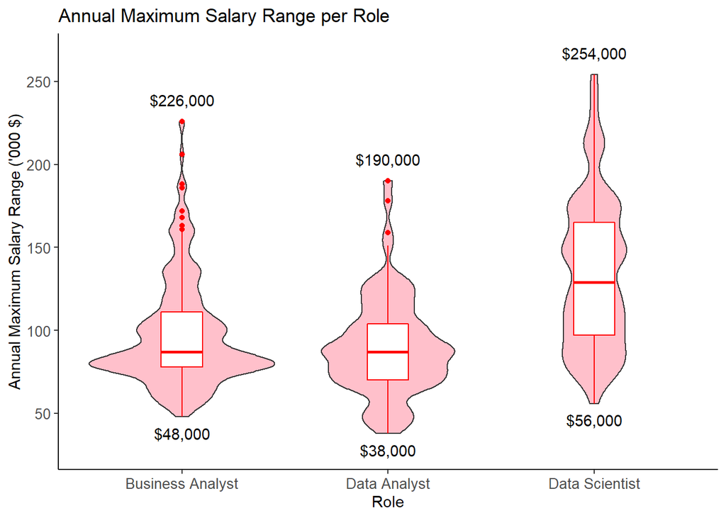

Figure 1.3: Annual maximum salary range per role. Data Scientists are the highest earners once again

```r
combined_sal_max <- combined %>%
  filter(salary_estimate != "-1",
         salary_basis == "annual") %>%
  group_by(role) %>%
  summarise(minimum = min(max_salary),
            maximum = max(max_salary))


combined %>%
  filter(salary_estimate != "-1",
         salary_basis == "annual") %>%
  ggplot(aes(role)) +
  geom_violin(aes(y = max_salary/1000), fill = "pink") +
  geom_boxplot(aes(y = max_salary/1000), color = "red", width = .2) +
  geom_text(data = combined_sal_max, aes(y = minimum/1000, label = scales::dollar(minimum)), nudge_y = -10) +
  geom_text(data = combined_sal_max, aes(y = maximum/1000, label = scales::dollar(maximum)), nudge_y = 13) +
  scale_y_continuous(breaks = seq(0, 250, 50)) +
  theme_classic() +
  labs(x = "Role",
       y = "Annual Maximum Salary Range ('000 $)",
       title = "Annual Maximum Salary Range per Role") +
  theme(axis.text = element_text(size = 10))
```

Based on all the above, it seems that data science roles are the best concerning salary.

### 1.3.2 ii. Location of the Job

The states with the highest number of jobs per role will be studied.

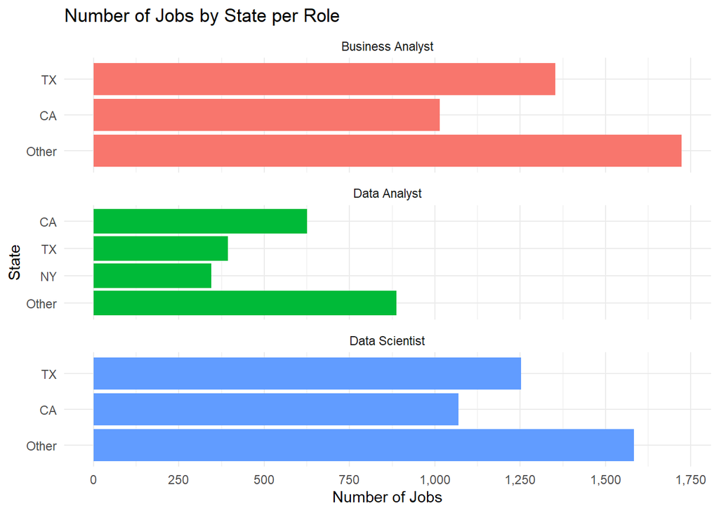

Figure 1.4: Number of jobs by state per role. California and Texas have the highest number of jobs

```r
combined %>%
  count(role, state) %>%
  mutate(state = case_when
         (role %in% c("Business Analyst", "Data Scientist") & n < 1000 ~ "Other",
           role == "Data Analyst" & n < 250 ~ "Other",
         TRUE ~ state)) %>%
  ggplot(aes(n, reorder_within(state, n, role), fill = role)) +
  geom_col(show.legend = FALSE) +
  scale_y_reordered() +
  scale_x_continuous(breaks = seq(0, 1750, 250),
                     labels = scales::label_comma()) +
  facet_wrap(vars(role), scales = "free_y", ncol = 1) +
  theme_minimal() +
  labs(x = "Number of Jobs",
       y = "State",
       title = "Number of Jobs by State per Role")
```

According to 1.4, Texas and California dominate the number of jobs in terms of state. Business analysts and Data scientists are very similar regarding the number of jobs per state, while data analysts have much fewer job numbers.

### 1.3.3 iii. Company Size

Jobs according to company size will now be analysed.

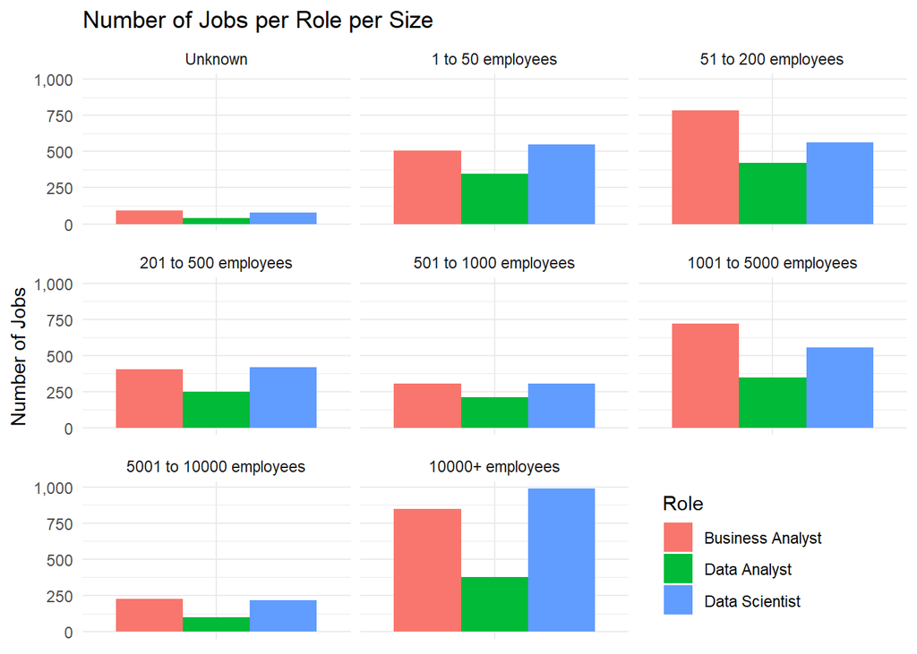

Figure 1.5: Number of jobs per company size per role. Data analysts have fewer jobs than business analysts and data scientists

```r
combined %>%
  filter(size != "-1") %>%
  ggplot(aes(size, fill = role)) +
  geom_bar(position = position_dodge()) +
  facet_wrap(vars(size), scales = "free_x") +
  scale_y_continuous(labels = scales::label_comma()) +
  theme_minimal() +
  theme(legend.position = c(.8, .15),
        axis.text.x = element_blank(),
        axis.title.x = element_blank()) +
  labs(y = "Number of Jobs",
       title = "Number of Jobs per Role per Size",
       fill = "Role")
```

1.5 shows that data analysts are not as in demand as the other two roles in all company sizes.

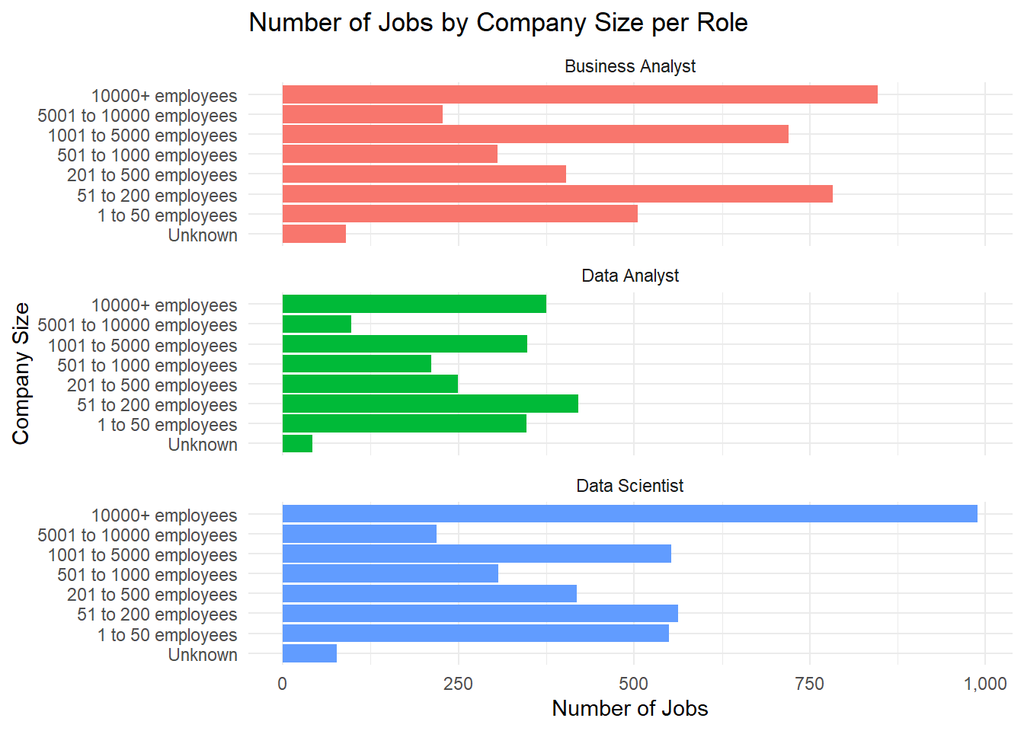

Figure 1.6: Number of jobs per company size per role. Data scientists generally work in companies with large numbers of employees, business and data analysists are more spread out

```r
combined %>%
  filter(size != "-1") %>%
  count(role, size) %>%
  ggplot(aes(n, size, fill = role)) +
  geom_col(show.legend = FALSE) +
  scale_x_continuous(labels = scales::label_comma()) +
  facet_wrap(vars(role), ncol = 1) +
  theme_minimal() +
  labs(x = "Number of Jobs",
       y = "Company Size",
       title = "Number of Jobs by Company Size per Role")
```

1.6 shows that data scientists generally work in companies with a large number of employees, while the other two roles are more spread out in terms of company size. Data analysts are not as in demand as business analysts and data scientists.

### 1.3.4 iv. Industry

The number of jobs per industry will be studied.

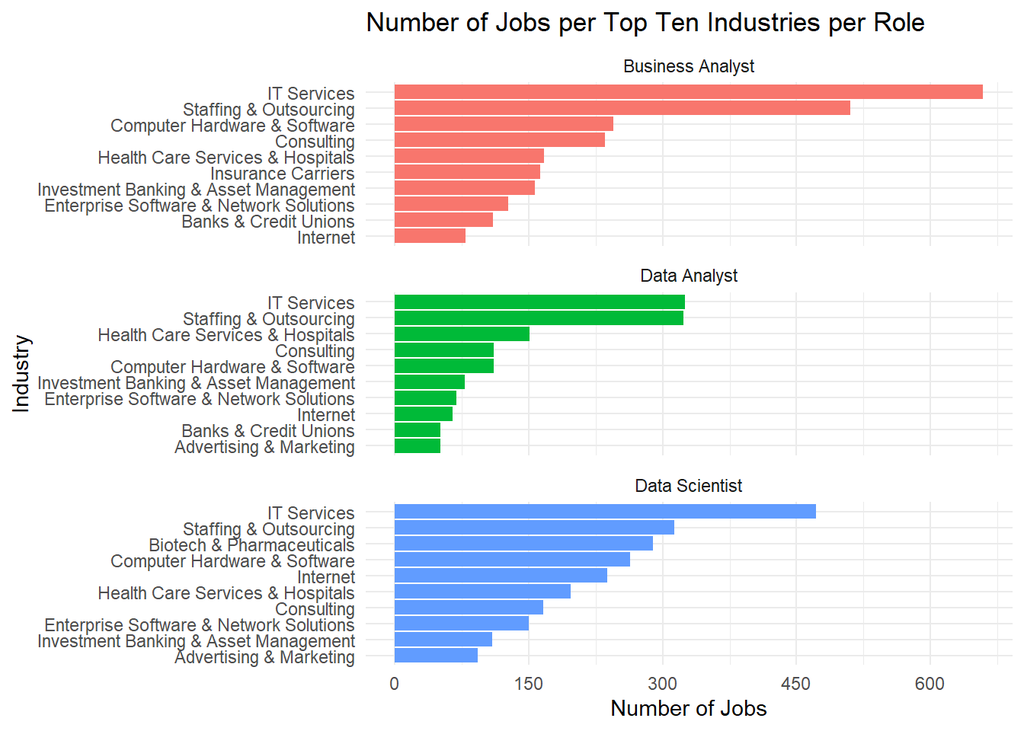

Figure 1.7: Number of jobs per top ten industries per role. IT Services and Staffing & Outsourcing are the most common industries

```r
combined %>%
  filter(industry != "-1") %>%
  group_by(role, industry) %>%
  tally() %>%
  slice_max(order_by = n, n = 10) %>%
  ggplot(aes(n, reorder_within(industry, n, role), fill = role)) +
  geom_col(show.legend = FALSE) +
  scale_y_reordered() +
  scale_x_continuous(breaks = seq(0, 600, 150)) +
  facet_wrap(vars(role), scales = "free_y", ncol = 1) +
  theme_minimal() +
  labs(x = "Number of Jobs",
       y = "Industry",
       title = "Number of Jobs per Top Ten Industries per Role")
```

Per 1.7, the **IT Services** and **Staffing & Outsourcing** are the most common industries across all the roles, this is especially true for business and data analyst jobs, data scientists, meanwhile, are more concentrated in the IT Services industry.

### 1.3.5 v. Sector

The number of jobs per sector will be compared.

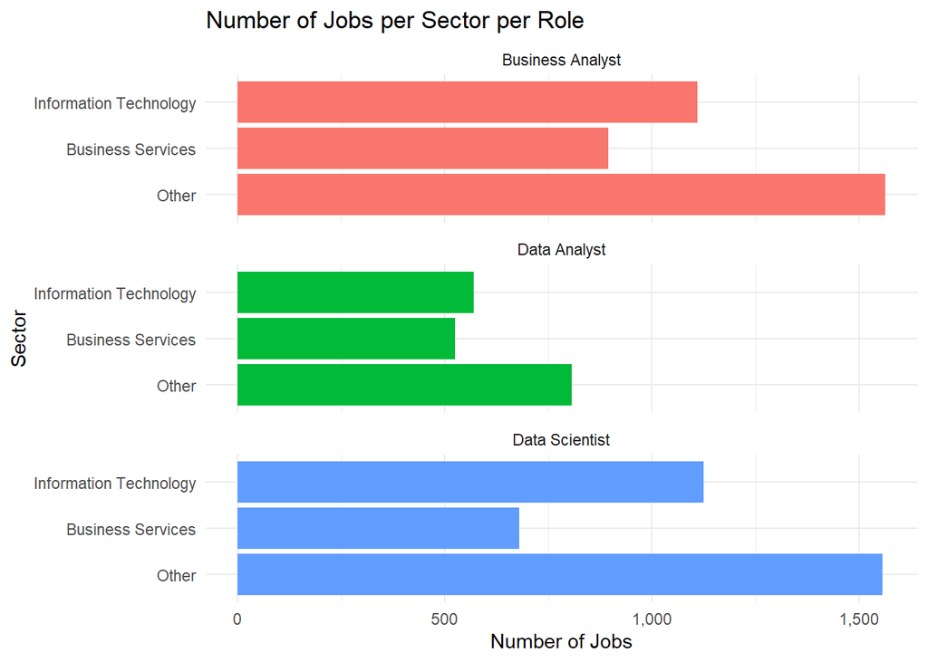

Figure 1.8: Number of jobs per sector per role. Information Technology and Business Services dominate the sectors

```r
combined %>%
  filter(sector != "-1") %>%
  count(role, sector) %>%
  mutate(sector = ifelse(sector %in% c("Information Technology", "Business Services"), sector, "Other")) %>%
  ggplot(aes(n, reorder_within(sector, n, role), fill = role)) +
  geom_col(show.legend = FALSE) +
  scale_y_reordered() +
  scale_x_continuous(labels = scales::label_comma()) +
  facet_wrap(vars(role), scales = "free_y", ncol = 1) +
  theme_minimal() +
  labs(x = "Number of Jobs",
       y = "Sector",
       title = "Number of Jobs per Sector per Role")
```

As shown in 1.8, **Information Technology** and **Business Services** dominate the sectors across all three roles. Business analysts and data scientists have very similar numbers per sector. Data analyst jobs are almost evenly split between Information Technology and Business Services, followed by all other sectors.

## 1.4 Question d

The salary ranges will be compared according to the source. Our analysis will only include annual figures. First we will compare the salary ranges regardless of role.

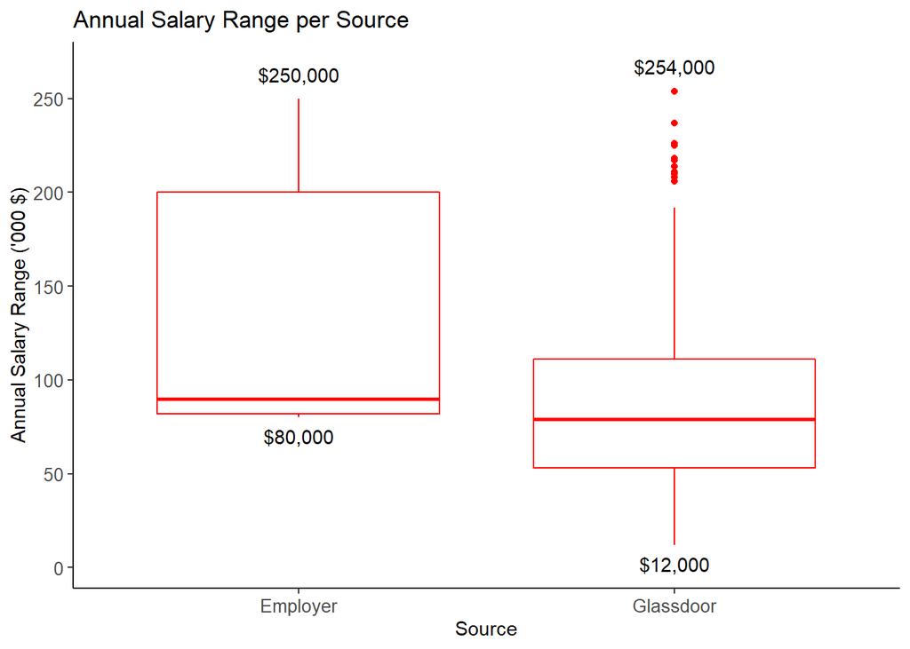

Figure 1.9: Salary range according to the source. Salary ranges provided by employers tend to be higher

```r
combined_source <- combined %>%
  filter(salary_estimate != "-1",
         salary_basis == "annual") %>%
  group_by(salary_source) %>%
  summarise(range = c(min_salary,max_salary),
            minimum = min(min_salary),
            maximum = max(max_salary)) %>%
  ungroup()

combined_source_lab <- combined_source %>%
  group_by(salary_source) %>%
  summarise(minimum = min(minimum),
            maximum = max(maximum),
            average = mean(range),
            median = median(range))

ggplot(combined_source, aes(salary_source)) +
geom_boxplot(aes(y = range/1000), color = "red") +
geom_text(data = combined_source_lab, aes(y = minimum/1000, label = scales::dollar(minimum)), nudge_y = -10) +
geom_text(data = combined_source_lab, aes(y = maximum/1000, label = scales::dollar(maximum)), nudge_y = 13) +
scale_y_continuous(breaks = seq(0, 250, 50)) +
theme_classic() +
labs(x = "Source",
     y = "Annual Salary Range ('000 $)",
     title = "Annual Salary Range per Source") +
theme(axis.text = element_text(size = 10))
```

It seems that my friend is correct in his assumption that if a salary range is provided by an employer it tends to be large. From 1.9 we can see that the median salary provided by employers is $90,000 versus $79,000 provided by Glassdoor. Moreover, the minimum salary provided by employers is $80,000 versus $12,000 provided by Glassdoor. The maximum salaries provided are similar between the two sources at around $250,000. We also observe that the salary range provided by employers is more distributed towards the higher end of the range versus the range provided by Glassdoor which is more evenly distributed.

We will dig deeper in to the comparison between the two sources by adding the roles into the analysis. There are no data analyst salary ranges provided by employers, therefore only business analysts and data scientists will be compared.

[figure not shown]

Figure 1.10: Salary range according to the source per role. Salary ranges provided by employers tend to be higher for both roles

```r
combined_source_role <- combined %>%
  filter(salary_estimate != "-1",
         salary_basis == "annual",
         role != "Data Analyst") %>%
  group_by(role, salary_source) %>%
  summarise(range = c(min_salary,max_salary),
            minimum = min(min_salary),
            maximum = max(max_salary)) %>%
  ungroup()

combined_role_source_lab <- combined_source_role %>%
  group_by(role, salary_source) %>%
  summarise(minimum = min(minimum),
            maximum = max(maximum),
            average = mean(range),
            median = median(range))

ggplot(combined_source_role, aes(role, color = salary_source)) +
geom_boxplot(aes(y = range/1000)) +
scale_y_continuous(breaks = seq(0, 250, 50)) +
theme_classic() +
labs(x = "Role",
     y = "Annual Salary Range ('000 $)",
     title = "Annual Salary Range per Role per Source",
     color = "Source") +
theme(axis.text = element_text(size = 10))
```

According to 1.10, the observation from the previous graph can be applied with segregation by role. Both business analysts and data scientists earn a higher median income when the salary range is provided by the employer. However, business analysts have the potential to earn higher salaries when the salary range is provided by Glassdoor.

## 1.5 question e

The relationship between state and salary will be studied.

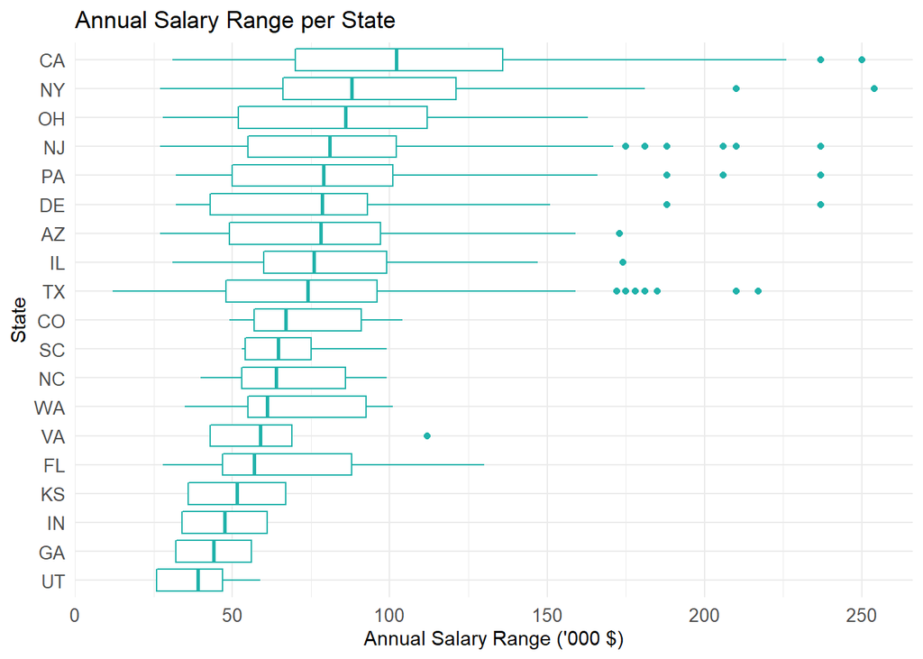

Figure 1.11: Annual salary range per state. CA has the highest median salary

```r
combined_state_sal <- combined %>%
  filter(salary_estimate != "-1",
         salary_basis == "annual") %>%
  group_by(state) %>%
  summarise(range = c(min_salary,max_salary),
            median = median(range)) %>%
  ungroup()

ggplot(combined_state_sal, aes(range/1000, reorder(state, median))) +
  geom_boxplot(color = "#20B2AA") +
  theme_minimal() +
  labs(x = "Annual Salary Range ('000 $)",
       y = "State",
       title = "Annual Salary Range per State") +
  theme(axis.text = element_text(size = 10))
```

1.11 suggests that salary is indeed associated with state by noting that the ranges differ widely by state, from a median salary of $39,000 in UT to that of $102,000 in Ca, with a range of different median salaries in between.

The relationship between state and sector will be studied.

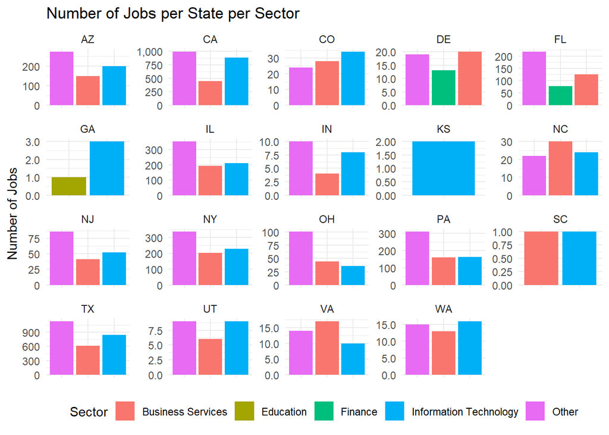

Figure 1.12: Relationship between states and sectors. Business Services and Information Technology are the dominant sectors in almost all the states

```r
combined_state_sect <- combined %>%
  filter(sector != "-1") %>%
  group_by(state, sector) %>%
  tally() %>%
  arrange(state, -n) %>%
  mutate(top_sects = ifelse(n %in% c(n[1], n[2]), sector, "Other"))

ggplot(combined_state_sect, aes(reorder_within(top_sects, n, top_sects), n, fill = top_sects)) +
  geom_col() +
  facet_wrap(vars(state), scales = "free") +
  scale_x_reordered() +
  scale_y_continuous(labels = scales::label_comma()) +
  theme_minimal() +
  theme(legend.position = "bottom",
        axis.text.x = element_blank(),
        axis.title.x = element_blank()) +
  labs(y = "Number of Jobs",
       title = "Number of Jobs per State per Sector",
       fill = "Sector")
```

1.12 shows that there is no particular relationship between state and sector as all the states except for DE, FL, GA and KS, have business services and information technology as two most popular sectors followed by all other sectors.

# 2 Exercise 2

```r
library(tidyverse)
library(fitzRoy)
library(cassowaryr)
library(plotly)
library(shiny)
```

```r
load("data/aflw_num.rda")
load("data/aflw.rda")
load("data/aflw_scags.rda")
```

## 2.1 Question a

There are 14 teams in the competition. There are 370 players. There are 7 rounds.

## 2.2 Question b

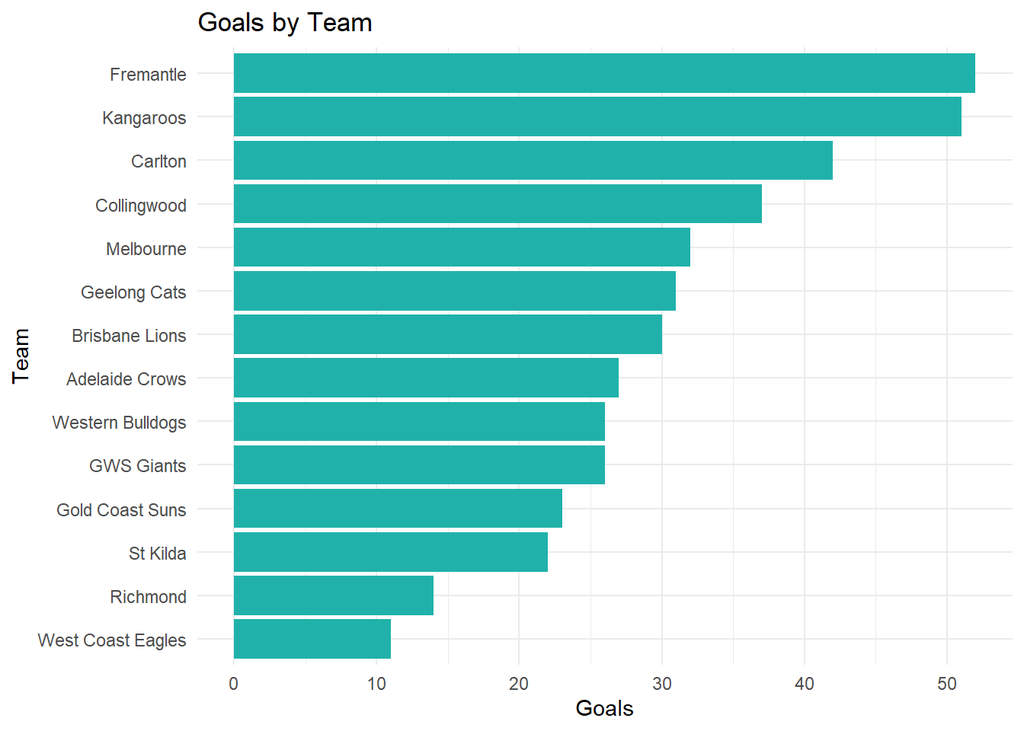

Figure 2.1: Goals by team. Frematle and Kangaroos are very close in the number of goals, but Fremantle just edges it

```r
aflw %>%
  group_by(team.name) %>%
  summarise(goals = sum(goals)) %>%
  ggplot(aes(goals, reorder(team.name, goals))) +
  geom_col(fill = "#20B2AA") +
  labs(x = "Goals",
       y = "Team",
       title = "Goals by Team") +
  theme_minimal()
```

According to 2.1, Fremantle and Kangaroos are neck-to-neck with just over 50 goals scored by each team, but Fremantle is just ahead. Based on the number of goals, **Fremantle** seems to be the team that is most likely to win if the season were completed.

## 2.3 Question c

A pairs plot of all the numeric variables would create 1,156 total plots, of which 561 are scatter plots.

## 2.4 Question d

For each player, the mean of each statistic will be calculated.

```r
player_summaries <- aflw %>%
  group_by(player.playerId) %>%
  summarise(across(is.numeric, mean)) %>%
  select(-c(round.roundNumber:player.player.player.playerJumperNumber, player.playerJumperNumber))
```

To find the pair of variables with the “L” shape, the variables pair with the highest **striated2** scagnostic is identified and plotted.

```r
aflw_scags %>%
  arrange(-striated2) %>%
  head(1)
```

```
## # A tibble: 1 x 15
## # Groups:   Var1 [1]
##   Var1    Var2  outlying stringy striated striated2 clumpy clumpy2 sparse skewed
##   <fct>   <fct>    <dbl>   <dbl>    <dbl>     <dbl>  <dbl>   <dbl>  <dbl>  <dbl>
## 1 hitouts boun~    0.442   0.890    0.759     0.926  0.704       0 0.0625  0.750
## # ... with 5 more variables: convex <dbl>, skinny <dbl>, monotonic <dbl>,
## #   splines <dbl>, dcor <dbl>
```

The pair is **hitouts** and **bounces**. We can see the “L” shape below

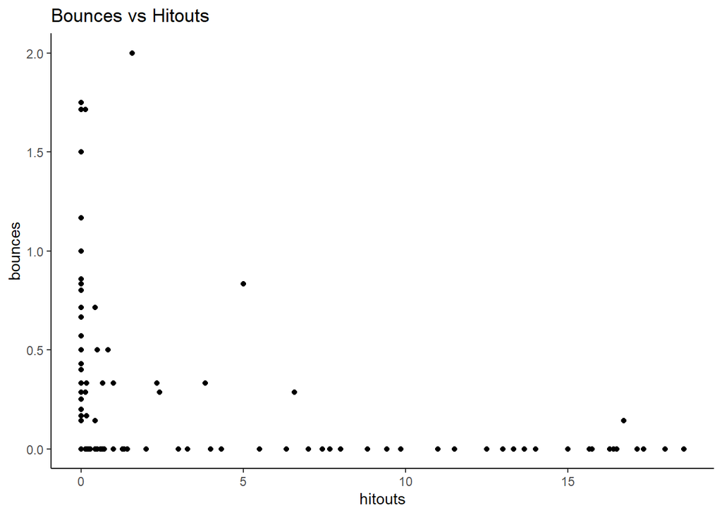

```r
ggplot(player_summaries, aes(hitouts, bounces)) +
  geom_point() +
  theme_classic() +
  labs(title = "Bounces vs Hitouts")
```

The figure shows that players who achieve hitouts almost exclusively never achieve bounces; conversely, players who achieve bounces almost never achieve hitouts.

## 2.5 question e

To find a pair of variables with a barrier, the variables pair with the highest **monotonic** scagnostic is identified and plotted.

```r
aflw_scags %>%
  arrange(-monotonic) %>%
  head(1)
```

```
## # A tibble: 1 x 15
## # Groups:   Var1 [1]
##   Var1   Var2   outlying stringy striated striated2 clumpy clumpy2 sparse skewed
##   <fct>  <fct>     <dbl>   <dbl>    <dbl>     <dbl>  <dbl>   <dbl>  <dbl>  <dbl>
## 1 clear~ clear~    0.227   0.705    0.271     0.353  0.753       0 0.0601  0.689
## # ... with 5 more variables: convex <dbl>, skinny <dbl>, monotonic <dbl>,
## #   splines <dbl>, dcor <dbl>
```

The pair is **clearances.totalClearances** and **clearances.stoppageClearances**.

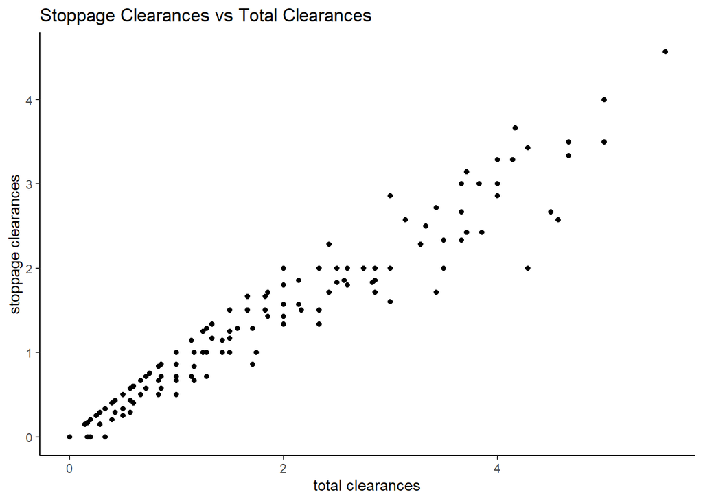

```r
ggplot(player_summaries, aes(clearances.totalClearances, clearances.stoppageClearances)) +
  geom_point() +
  theme_classic() +
  labs(x = "total clearances",
       y = "stoppage clearances",
       title = "Stoppage Clearances vs Total Clearances")
```

The figure shows that there is barrier of having higher stoppage clearances than total clearances, since it is impossible for that to happen.

## 2.6 question f

```r
shinyApp(
ui <- fluidPage(
  plotlyOutput("parcoords"),
  verbatimTextOutput("data")),


server <- function(input, output, session) {
  aflw_numeric <- aflw_scags[,3:15]
  output$parcoords <- renderPlotly({
    dims <- Map(function(x, y) {
      list(values = x, range = c(0,1), label = y)
    }, aflw_numeric, names(aflw_numeric), USE.NAMES = FALSE)
    plot_ly(type = 'parcoords', dimensions = dims,
            source = "pcoords") %>%
      layout(margin = list(r = 30)) %>%
      event_register("plotly_restyle")
  })

  ranges <- reactiveValues()
  observeEvent(event_data("plotly_restyle", source = "pcoords"),
               {
                 d <- event_data("plotly_restyle", source = "pcoords")
                 # what is the relevant dimension (i.e. variable)?
                 dimension <- as.numeric(stringr::str_extract(names(d[[1]]),
                                                              "[0-9]+"))
                 # If the restyle isn't related to a dimension, exit early.
                 if (!length(dimension)) return()
                 # careful of the indexing in JS (0) versus R (1)!
                 dimension_name <- names(aflw_numeric)[[dimension + 1]]
                 # a given dimension can have multiple selected ranges
                 # these will come in as 3D arrays, but a list of vectors
                 # is nicer to work with
                 info <- d[[1]][[1]]
                 ranges[[dimension_name]] <- if (length(dim(info)) == 3) {
                   lapply(seq_len(dim(info)[2]), function(i) info[,i,])
                 } else {
                   list(as.numeric(info))
                 }
               })
  ## filter to the rows that match the selection ranges
  aflw_selected <- reactive({
    keep <- TRUE
    for (i in names(ranges)) {
      range_ <- ranges[[i]]
      keep_var <- FALSE
      for (j in seq_along(range_)) {
        rng <- range_[[j]]
        keep_var <- keep_var | dplyr::between(aflw_scags[[i]],
                                              min(rng), max(rng))
      }
      keep <- keep & keep_var
    }
    aflw_scags[keep, ]
  })
  output$data <- renderPrint({
    tibble::as_tibble(aflw_selected())
  })
},

options = list(height = 600)
)
```

### 2.6.1 i.

From the parallel coordinate plot, we can see **positive** associations between some variables such as between *stringy* and *striated*, *striated* and *striated2*, *monotonic* and *splines*, and *splines* and *dcor*. We can observe **negative** associations such as between *clumpy* and *sparse*, *monotonic* and *striated2*, *splines* and *striated2*, and *dcor* and *striated2*. **Outliers** also exist in some variable combinations such as between *clumpy* and *clumpy2*. **Clusters** can also be found in the combination between *striated* and *striated2*.

### 2.6.2 ii.

Pairs that have high values on convex tend to have low values on **outlying**, high values on **stringy**, low values on **striated**, moderately high values on **skewed**, medium values on **skinny**, and values across the full range on **splines**.

### 2.6.3 iii.

Pairs of variables that have high values on skewed tend to have moderately low values on **outlying**, high values on **stringy**, high values on **striated**, and low values on **splines**.

### 2.6.4 iv.

**marksInside50** and **disposal** is in outlier regarding the *clumpy* and *clumpy2* variables since it has high values for both variables, while for most other variable combinations, the values for *clumpy2* are very low or zero.

# 3 Exercise 3

```r
library(tidyverse)
library(nullabor)
library(gridExtra)
```

```r
control <- read_csv("data/control_data.csv") %>%
  mutate(group = "control")

experiment <- read_csv("data/experiment_data.csv") %>%
  mutate(group = "experiment")

combined <- rbind(control, experiment) %>%
  mutate(group = factor(group)) %>%
  separate(Date, into = c("wday", "day"), sep = ", ", remove = FALSE) %>%
  mutate(day = as.Date(day, format = "%b %e"),
         wday = factor(wday, levels = c("Mon", "Tue", "Wed", "Thu", "Fri", "Sat", "Sun")))
```

## 3.1 a.

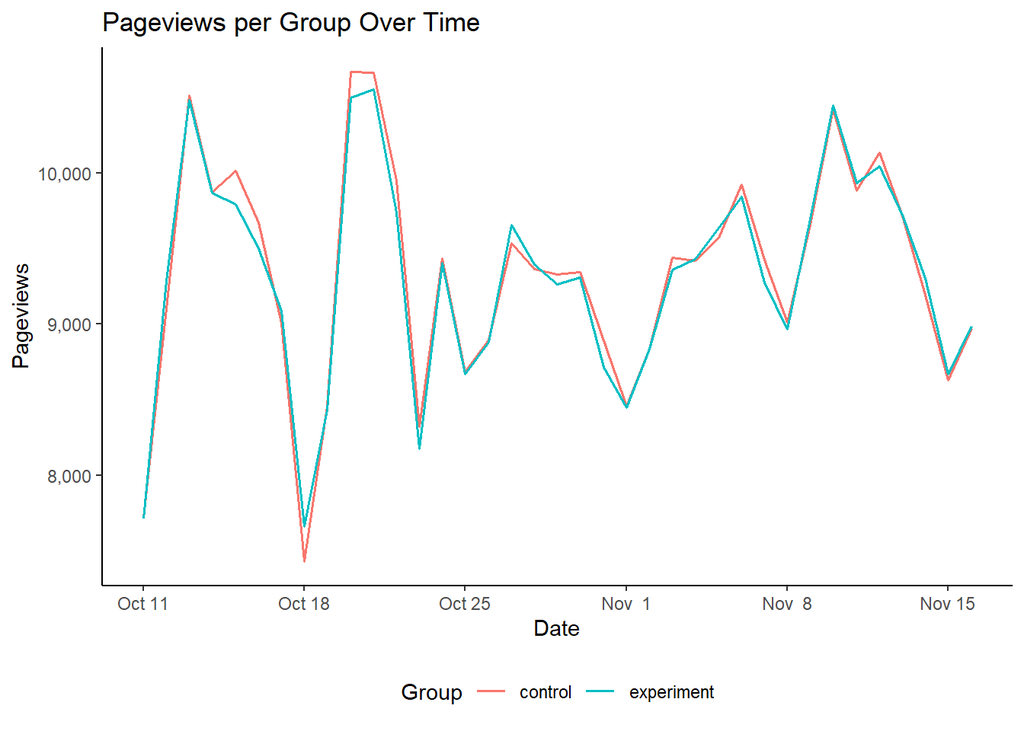

Figure 3.1: Pageviews per group plotted over time. The two groups follow each other almost exactly

```r
ggplot(combined, aes(day, Pageviews, color = group)) +
  geom_line(size = .7) +
  theme_classic() +
  scale_x_date(date_breaks = "1 week", date_labels = "%b %e") +
  scale_y_continuous(labels = scales::label_comma()) +
  labs(x = "Date",
       y = "Pageviews",
       color = "Group",
       title = "Pageviews per Group Over Time") +
  theme(legend.position = "bottom")
```

3.1 shows that the two groups have almost the same number of pageviews per date over time.

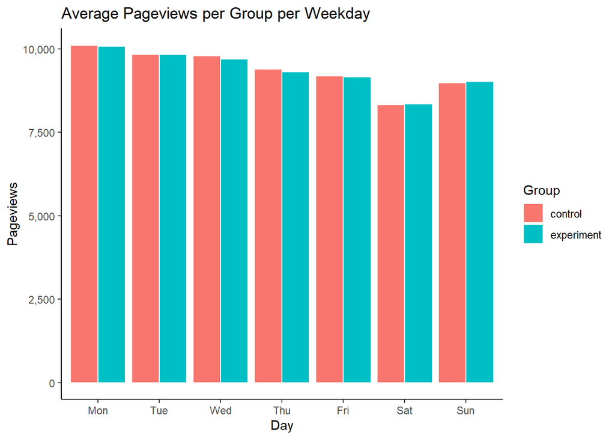

Figure 3.2: Average pageviews per weekday. Saturdays have the lowest average pageviews

```r
combined %>%
  group_by(group, wday) %>%
  summarise(average = mean(Pageviews)) %>%
  ggplot(aes(wday, average, fill = group)) +
  geom_col(position = "dodge", color = "white") +
  scale_y_continuous(labels = scales::label_comma()) +
  theme_classic() +
  labs(x = "Day",
       y = "Pageviews",
       fill = "Group",
       title = "Average Pageviews per Group per Weekday")
```

Through 3.2 we can see that Saturday has the lowest number of average pageviews. Again, we can see that the two groups match each other almost exactly per each day.

## 3.2 b.

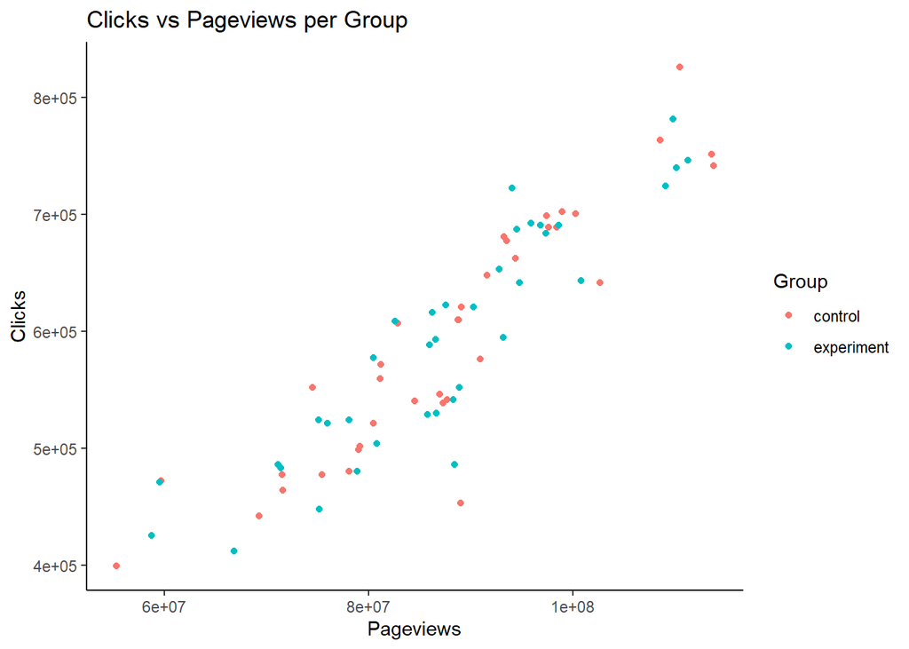

```r
ggplot(combined, aes(Pageviews^2, Clicks^2, color = group)) +
  geom_point() +
  labs(color = "Group",
       title = "Clicks vs Pageviews per Group",
       x = "Pageviews",
       y = "Clicks") +
  theme_classic()
```

After taking the power transformation of both variables, there is a strong positive relationship linear relationship between Clicks and Pageviews, there is no difference between the two group regarding clicks.

## 3.3 c.

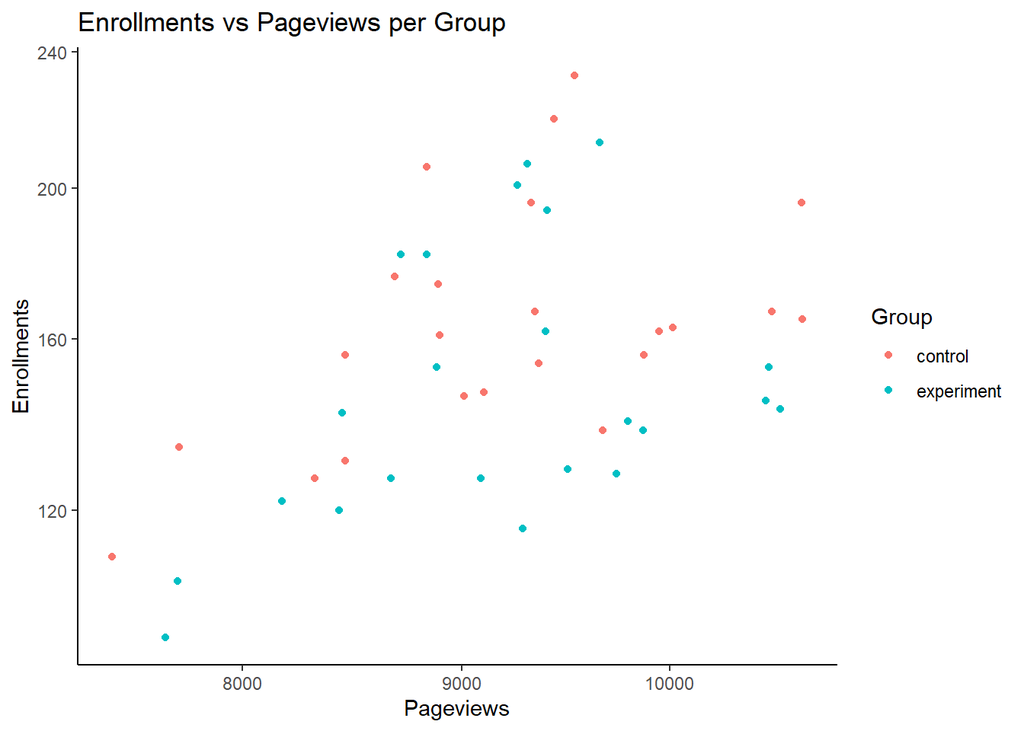

```r
ggplot(combined, aes(Pageviews, Enrollments, color = group)) +
  geom_point() +
    scale_x_sqrt() +
    scale_y_sqrt() +
  labs(color = "Group",
       title = "Enrollments vs Pageviews per Group",
       x = "Pageviews",
       y = "Enrollments") +
  theme_classic()
```

After taking the square root of both variables, we can see a positive nonlinear relationship. There is no difference between the two groups.

## 3.4 d

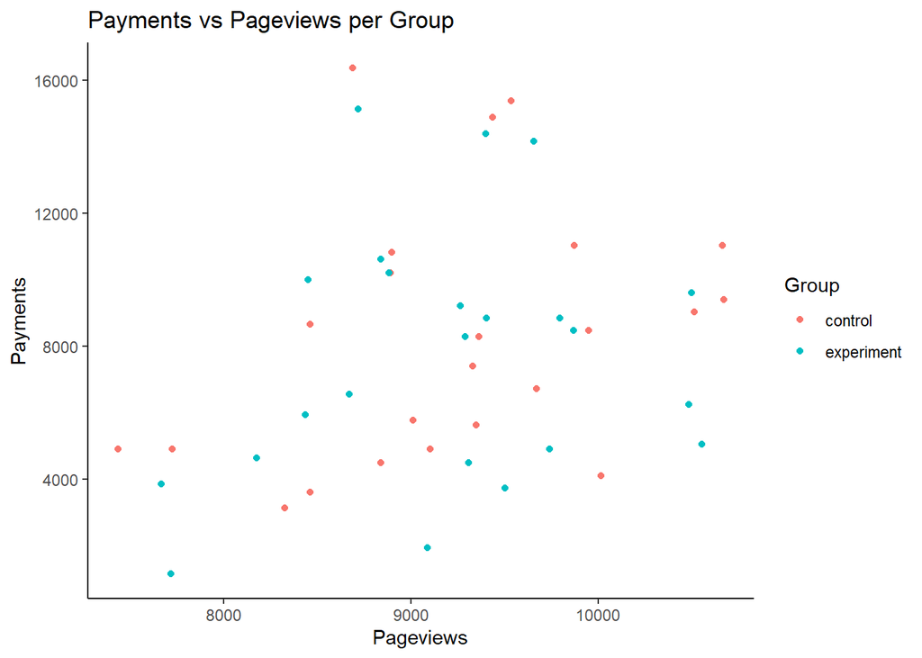

```r
ggplot(combined, aes(Pageviews, Payments^2, color = group)) +
  geom_point() +
  labs(color = "Group",
       title = "Payments vs Pageviews per Group",
       x = "Pageviews",
       y = "Payments") +
  theme_classic()
```

After taking the square of Payments, we can see a slightly positive nonlinear relationship between payments and pageviews. Again, there is no difference between the groups.

## 3.5 e.

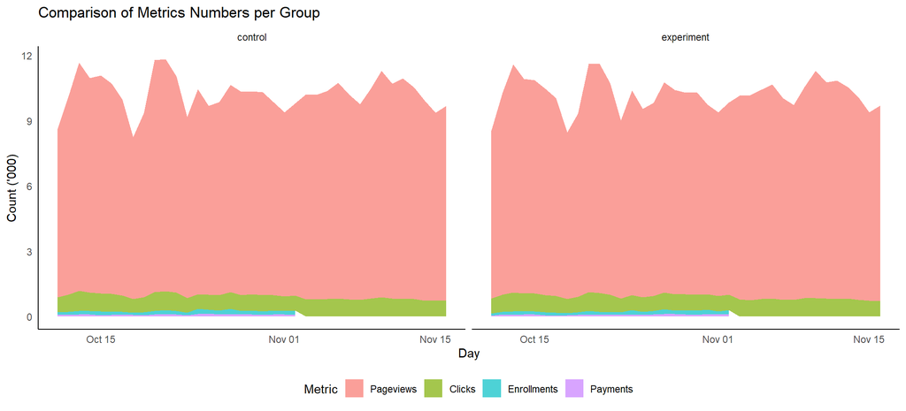

Figure 3.3: A comparison of the metrics counts per group. The two groups are almost identical

```r
combined_long <- combined %>%
  pivot_longer(cols = Pageviews:Payments,
               names_to = "metric",
               values_to = "count") %>%
  mutate(metric = factor(metric, levels = c("Pageviews", "Clicks", "Enrollments", "Payments")))

ggplot(combined_long, aes(day, count/1000, fill = metric)) +
  geom_area(alpha = .7) +
  facet_wrap(vars(group)) +
  theme_minimal() +
  theme(legend.position = "bottom",
        panel.grid = element_blank(),
        axis.line = element_line(color = "black")) +
  labs(x = "Day",
       y = "Count ('000)",
       fill = "Metric",
       title = "Comparison of Metrics Numbers per Group")
```

According to 3.3, the two groups are almost identical in terms of counts per metric per day.

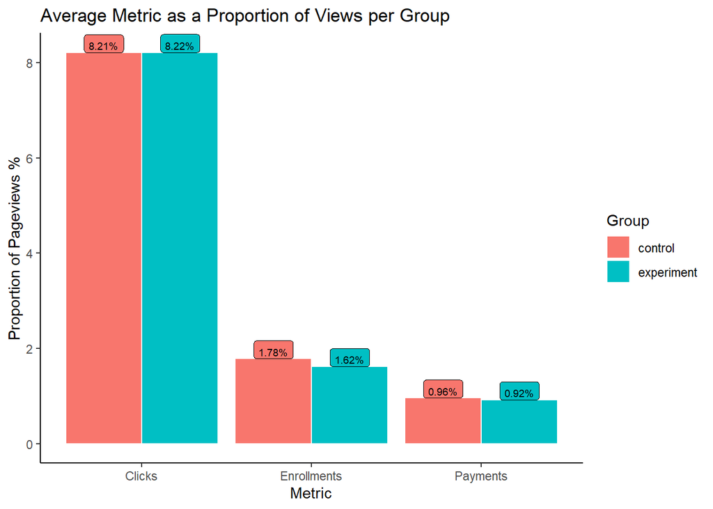

Figure 3.4: Average proportion of pageviews per metric per group. Again the two groups are very similar

```r
combined_prop <- combined %>%
  mutate(clicks_prop = Clicks / Pageviews * 100,
         enrol_prop = Enrollments / Pageviews * 100,
         pay_prop = Payments / Pageviews * 100)

combined_prop %>%
  group_by(group) %>%
  summarise(average_clicks = mean(clicks_prop, na.rm = TRUE),
            average_enrol = mean(enrol_prop, na.rm = TRUE),
            average_pay = mean(pay_prop, na.rm = TRUE)) %>%
  ungroup() %>%
  pivot_longer(cols = average_clicks:average_pay,
               names_to = "metric",
               values_to = "prop") %>%
  mutate(metric = factor(metric, levels = c("average_clicks", "average_enrol", "average_pay"))) %>%
  ggplot(aes(metric, prop, fill = group)) +
  geom_col(position = "dodge", color = "white") +
  geom_label(aes(label = scales::percent(prop, scale = 1, accuracy = .01)), position = position_dodge(width = .9), vjust = 0, size = 2.5, show.legend = FALSE) +
  labs(x = "Metric",
       y = "Proportion of Pageviews %",
       fill = "Group",
       title = "Average Metric as a Proportion of Views per Group") +
  scale_x_discrete(labels = c("Clicks", "Enrollments", "Payments")) +
  theme_classic()
```

3.4 shows that average proportion of pageviews are almost identical per metric per group. For both groups, just over 8% of visitors click on the page, just under 2% of visitors enrol, and just under 1% of visitors make a payment.

Based on all the above, the A-B test shows that no impact was made by the additional factor.

## 3.6 f.

For the lineup plot, a boxplot of the clicks as a proportion of views for both groups is plotted. The method used to generate the null plots is the permute method, as both groups will be permuted in position of the boxplots in the plots of the lineup, so as to assess if there is a noticeable difference between the two groups when permuted.

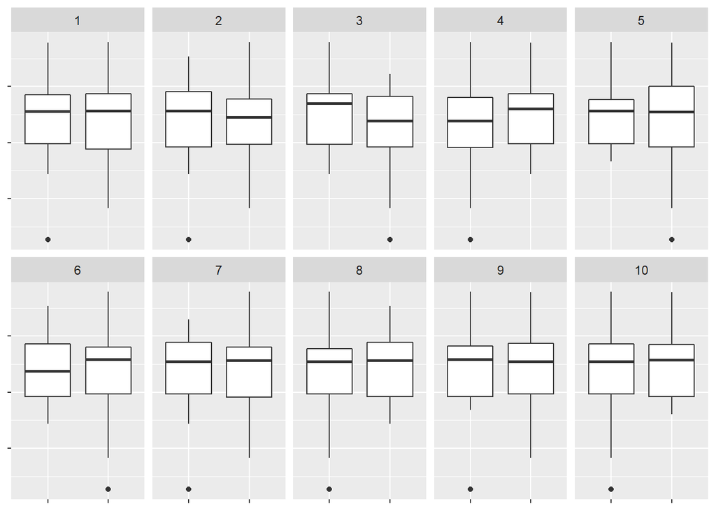

```r
method <- null_permute("group")

set.seed(1)
line_df <- lineup(method, true = combined_prop, n = 10)

line_df %>%
  ggplot(aes(group, clicks_prop)) +
  geom_boxplot() +
  facet_wrap(~.sample, nrow = 2) +
  theme(axis.text = element_blank(),
        axis.title = element_blank())
```

```r
decrypt("VrFX 0GgG 8s Lxd8g8xs Am")
```

```
## [1] "True data in position  9"
```

Based on my own evaluation of the lineup plots, I would not distinguish the true data at position 9 to be different from the other plots, therefore the null hypothesis that there is no real difference between the two groups holds true, and the flow is practically the same between the two groups.

# 4 Exercise 4

```r
library(tidyverse)
library(nullabor)
library(kableExtra)
```

```r
chol <- read_csv("data/Cholesterol_R.csv")
vis_inf <- read_csv("data/visinf-results.csv")
```

## 4.1 a.

The tests to be conducted below will assess if there is a significant difference between the margarine brands in the mean of the cholesterol **reduction** after four weeks, as such a new variable measuring the cholesterol reduction after four weeks will be created, and will be the basis of the forthcoming analysis.

```r
# create 4 week difference variable
chol <- chol %>%
  mutate(red_4weeks = Before - After4weeks)
```

The two-sample t-test is conducted:

```r
with(chol,
     t.test(red_4weeks[Margarine == "A"],
            red_4weeks[Margarine == "B"]))
```

```
##
##  Welch Two Sample t-test
##
## data:  red_4weeks[Margarine == "A"] and red_4weeks[Margarine == "B"]
## t = -2.5186, df = 15.934, p-value = 0.02285
## alternative hypothesis: true difference in means is not equal to 0
## 95 percent confidence interval:
##  -0.2967641 -0.0254581
## sample estimates:
## mean of x mean of y
## 0.4855556 0.6466667
```

The Wilcoxon rank sum test is conducted:

```r
with(chol,
     wilcox.test(red_4weeks[Margarine == "A"],
                 red_4weeks[Margarine == "B"]))
```

```
##
##  Wilcoxon rank sum test with continuity correction
##
## data:  red_4weeks[Margarine == "A"] and red_4weeks[Margarine == "B"]
## W = 16, p-value = 0.03388
## alternative hypothesis: true location shift is not equal to 0
```

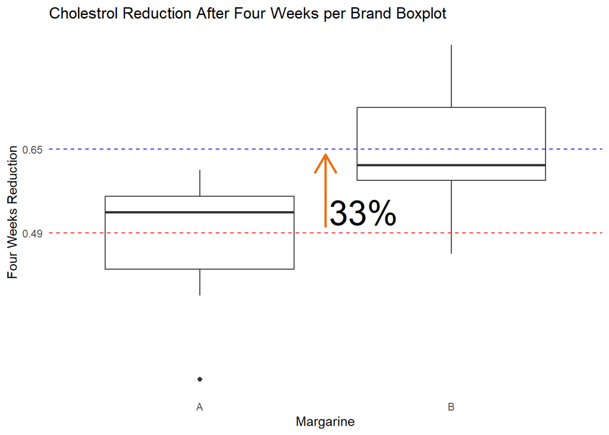

Figure 4.1: Four week reduction in cholesterol per brand. Brand B achieved one-third greater reduction than A

```r
a_mean <- round(mean((chol %>% filter(Margarine == "A"))$red_4weeks), 2)
b_mean <- round(mean((chol %>% filter(Margarine == "B"))$red_4weeks), 2)

ggplot(chol, aes(Margarine, red_4weeks)) +
  geom_boxplot() +
  geom_hline(yintercept = a_mean, color = "red", linetype = "dashed") +
  geom_hline(yintercept = b_mean, color = "blue", linetype = "dashed") +
  theme_minimal() +
  scale_y_continuous(breaks = c(a_mean, b_mean)) +
  theme(panel.grid = element_blank()) +
  labs(y = "Four Weeks Reduction",
       title = "Cholestrol Reduction After Four Weeks per Brand Boxplot") +
  annotate("segment", x = 1.5, xend = 1.5, y = .5, yend = .64, colour = "#EC7014", size = 1,
           arrow = arrow(ends = "last")) +
  annotate("text", x = 1.65, y = .53, label = "33%", size = 10)
```

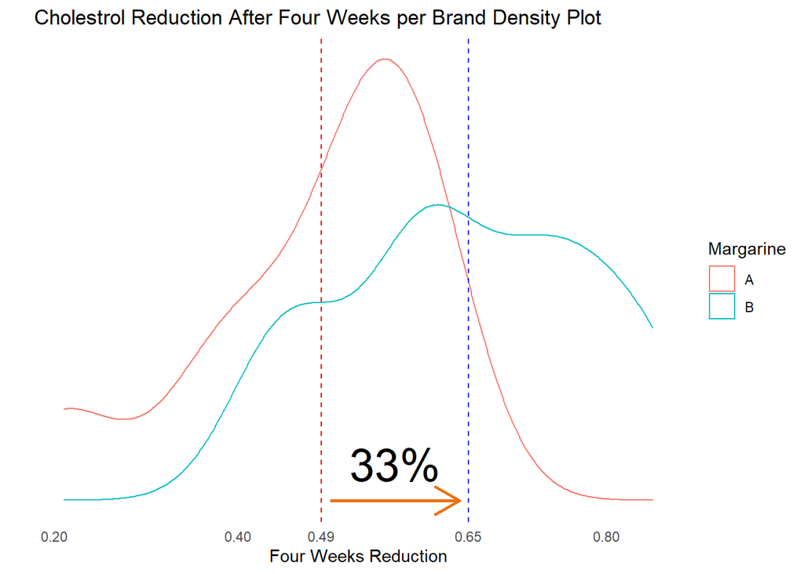

Figure 4.2: Four week reduction in cholesterol per brand. Brand B achieved one-third greater reduction than A

```r
ggplot(chol, aes(red_4weeks, color = Margarine)) +
  geom_density() +
  geom_vline(xintercept = a_mean, color = "red", linetype = "dashed") +
  geom_vline(xintercept = b_mean, color = "blue", linetype = "dashed") +
  theme_minimal() +
  scale_x_continuous(breaks = c(.2, .4, a_mean, b_mean, .8)) +
  labs(y = "",
       x = "Four Weeks Reduction",
       title = "Cholestrol Reduction After Four Weeks per Brand Density Plot") +
  theme(axis.text.y = element_blank(),
        panel.grid = element_blank()) +
  annotate("segment", x = .5, xend = .64, y = 0, yend = 0, colour = "#EC7014", size = 1,
           arrow = arrow(ends = "last")) +
  annotate("text", x = .57, y = .3, label = "33%", size = 10)
```

The p-values of both the two-sample t-test and the Wilcoxon rank sum test are both under 0.05, leading to the rejection of the null hypothesis that the means in the reduction of both brands are not significantly different. This is further supported by figures 4.1 and 4.2 which show that Margarine B achieved an approximately 33% greater reduction in cholesetrol on average than Margarine A. The figures also show that Margarine B has more observations with a greater reduction than the average reduction in cholesterol than Margarine A. It can therefore be concluded that the mean differences are significantly different between the two Margarines, and Margarine B is superior with regards to cholesterol reduction.

## 4.2 b.

The lineup is constructed as follows

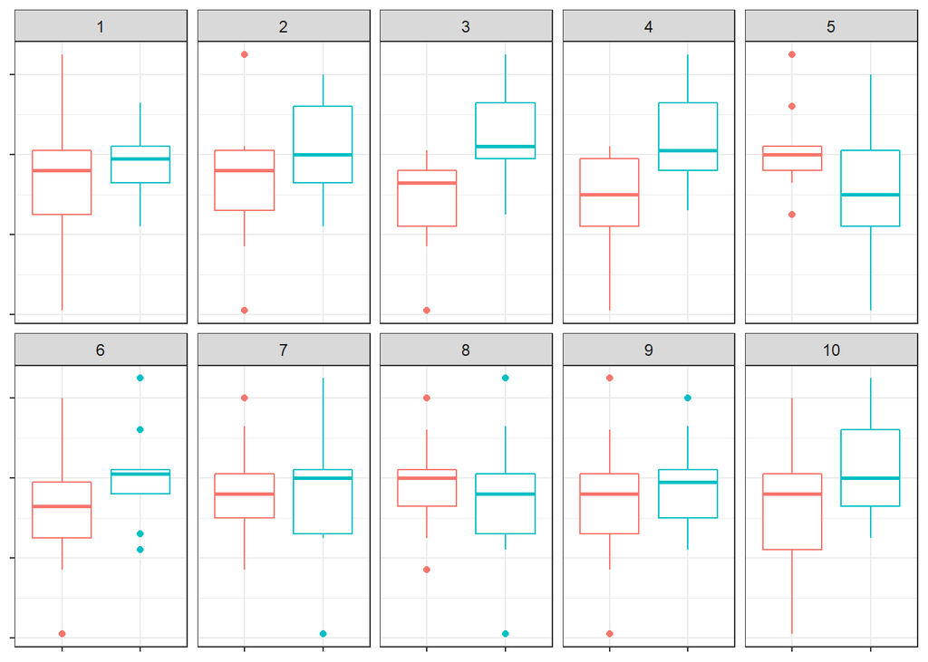

```r
set.seed(1)
method <- null_permute("red_4weeks")

line_df <- lineup(method, true = chol, n = 10)

ggplot(line_df, aes(Margarine, red_4weeks, color = Margarine)) +
  geom_boxplot() +
  guides(color = "none") +
  facet_wrap(~.sample, nrow = 2) +
  theme_bw() +
  theme(axis.text = element_blank(),
        axis.title = element_blank())
```

```r
decrypt("VrFX 0GgG 8s Lxd8g8xs A7")
```

```
## [1] "True data in position  3"
```

```r
1 - pbinom(1, 13, 0.05)
```

```
## [1] 0.1354239
```

Based on the responses I received, only two people out of 13 correctly identified the true plot. The p-value is approximately equal to 0.1354, this is larger than the alpha of 0.05, therefore it can be concluded that the data adheres to the null distribution, and we fail to reject the null hypothesis that two brands are significantly different, based on the results of the lineup analysis using boxplot.

## 4.3 c.

The power of each lineup is calculated, as well as the mean power and standard deviation for each visual statistic

```r
lineup_power <- vis_inf %>%
  group_by(lineup_id, vis) %>%
  summarise(power = mean(detected == "yes")) %>%
  ungroup()

lineup_power
```

```
## # A tibble: 180 x 3
##    lineup_id vis     power
##    <chr>     <chr>   <dbl>
##  1 L001      violin  0.7
##  2 L002      boxplot 0.475
##  3 L003      dotplot 0.642
##  4 L004      violin  0.608
##  5 L005      boxplot 0.517
##  6 L006      dotplot 0.658
##  7 L007      violin  0.6
##  8 L008      boxplot 0.542
##  9 L009      dotplot 0.533
## 10 L010      violin  0.567
## # ... with 170 more rows
```

```r
lineup_power %>%
  group_by(vis) %>%
  summarise(mean_power = mean(power),
            sd_power = sd(power)) %>%
  kable(digits = 4, col.names = c("Visual Statistic", "Power Mean", "Power Standard Deviation")) %>%
  kable_styling(bootstrap_options = c("striped", "hover"))
```

| Visual Statistic | Power Mean | Power Standard Deviation |
| --- | --- | --- |
| boxplot | 0.4963 | 0.0451 |
| dotplot | 0.6107 | 0.0468 |
| violin | 0.6006 | 0.0437 |

Based on the results, the dotplot is the best visual statistic as it achieved the highest power mean.